# DVF Script 1

[Boris Mericskay](https://perso.univ-rennes2.fr/boris.mericskay) et [Florent Demoraes](https://perso.univ-rennes2.fr/florent.demoraes)

02/07/2021 - Mise à jour 08/10/2026

# 1 PRÉPARATION DES DONNÉES DVF OPENDATA

Cette première partie du script a comme objectif de préparer les données DVF en opendata (apurement, filtrage, agrégation,…) avant de commencer les analyses.

Seul le package `tidyverse` dédié à la manipulation de données est nécessaire.

```r
library(tidyverse)
```

## 1.1 Chargement du jeu de données

Dans le cadre de cet exercice, ce sont les données [« DVF géolocalisées »](https://www.data.gouv.fr/fr/datasets/5cc1b94a634f4165e96436c1/), enrichies par Etalab qui sont utilisées. La base initiale pour les quatre départements bretons (Côtes-d’Armor, Finistère, Ille-et-Vilaine et Morbihan) recense entre le 1er janvier 2014 et le 31 décembre 2019, 446 818 mutations distinctes correspondant à 1 034 029 lignes et 40 colonnes dans la base de données.

```r
DVF <- read.csv("Donnees/importfichier.csv", encoding = "UTF-8")
dim(DVF)
```

```
## [1] 1034029      40
```

## 1.2 Filtre et nettoyage des données

### 1.2.1 Etape1 -> Sélection des mutations de type “Ventes” de “Maison” et “Appartement’

```r
etape1 <- DVF %>% filter(nature_mutation == "Vente")
etape1bis <- etape1 %>% filter(type_local == "Maison" | type_local == "Appartement")
```

### 1.2.2 Etape2 -> Sélection et renommage des variables

```r
etape2 <- etape1bis %>% select(id = id_mutation,
                               disposition = numero_disposition,
                               parcelle = id_parcelle,
                               date = date_mutation,
                               nature = nature_mutation,
                               codecommune = code_commune,
                               departement = code_departement,
                               type = type_local,
                               surface = surface_reelle_bati,
                               piece = nombre_pieces_principales,
                               prix = valeur_fonciere,
                               latitude,
                               longitude)
```

### 1.2.3 Etape3 -> Remplacement des cellules vides par des NA et suppression des NA

```r
etape2[etape2 == ""] <- NA
etape3 <- etape2 %>% na.omit()
```

## 1.3 Suppression des doublons et des mutations multiventes

### 1.3.1 Etape4 -> Sélections des mutations simples

#### 1.3.1.1 Regrouper les transactions selon l’id, la surface et le prix de vente

```r
# pour vérifier s'il y a des multiventes (lignes partageant le même id, le même prix et la même surface)
table(duplicated(etape3[c("id", "prix", "surface")])) # Le résultat indique combien de lignes sont des multiventes (TRUE) et combien ne le sont pas (FALSE).
```

```
##
##  FALSE   TRUE
## 285117  55684
```

```r
# Création d'un tableau sans multiventes
unique <- etape3 %>%
  distinct(id, prix, surface, .keep_all = TRUE) # Si plusieurs lignes ont la même valeur pour id, prix et surface, seule la première occurrence est conservée. keep_all = TRUE signifie qu'on garde toutes les colonnes de l'objet etape3

# Nombre de combinaisons prix-surface distinctes pour chaque id
nbunique <- unique %>%
  group_by(id) %>%
  summarise(nb = n())
```

#### 1.3.1.2 Suppression des doublons et des mutations multiventes

```r
# Filtrage pour ne garder que les mutations simples
etape4 <- nbunique %>%
  filter(nb == 1)
```

### 1.3.2 Etape5 -> Création d’une table avec l’ensemble des colonnes, sans doublon

```r
etape5 <- unique %>%
  filter(id %in% etape4$id) %>%
  select(id, date, type, nature, codecommune, prix, surface,
         piece, latitude, longitude)
```

### 1.3.3 Modification du format des colonnes (nombres entiers -> nombres réels)

```r
etape5$prix <- as.numeric(etape5$prix)
etape5$surface <- as.numeric(etape5$surface)
etape5$piece <- as.numeric(etape5$piece)
```

## 1.4 Suppression des valeurs aberrantes

### 1.4.1 Fixer un seuil minimal des prix (percentiles)

```r
quantile(etape5$prix, 0.01)
```

```
##    1%
## 15000
```

### 1.4.2 Fixer un seuil maximal des prix (histogramme)

```r
options(scipen=999)
summary(etape5$prix)
```

```
##       Min.    1st Qu.     Median       Mean    3rd Qu.       Max.
##          0      82192     133523     175069     195000 2086000000
```

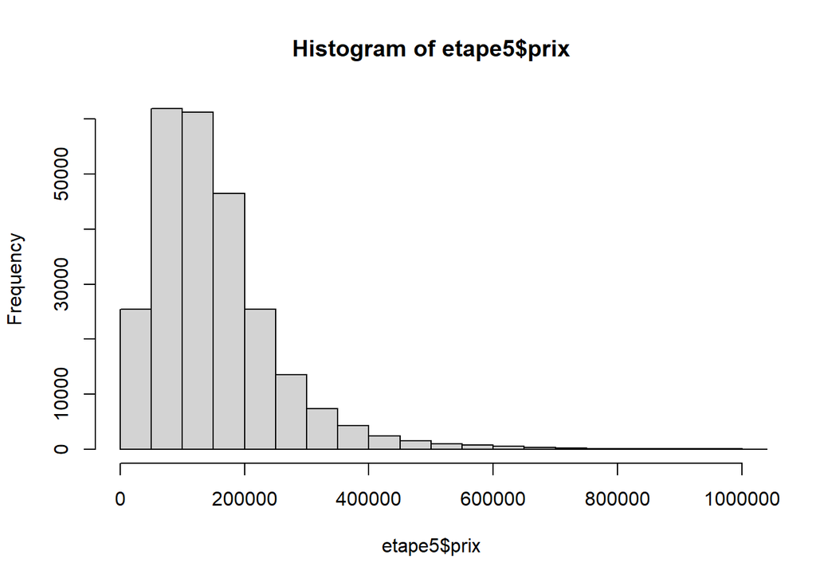

```r
hist(etape5$prix, breaks = 50000, xlim = c(0,1000000))
```

### 1.4.3 Créer deux jeux de données (maisons / appartements)

```r
Maisons <- etape5 %>% filter(type == 'Maison')
Appartements <- etape5 %>% filter (type == 'Appartement')
```

### 1.4.4 Fixer un seuil maximal des surfaces (histogramme)

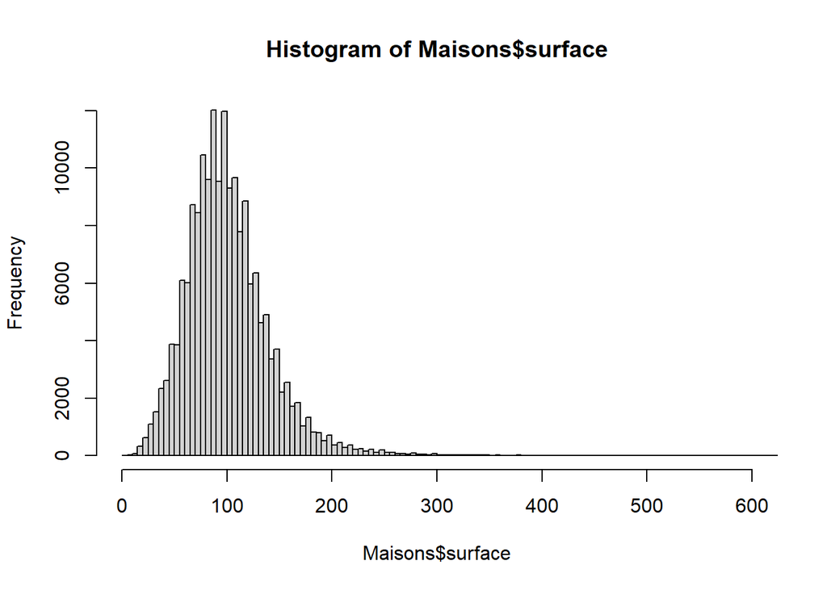

```r
hist(Maisons$surface, nclass = 500, xlim = c(0,600))
```

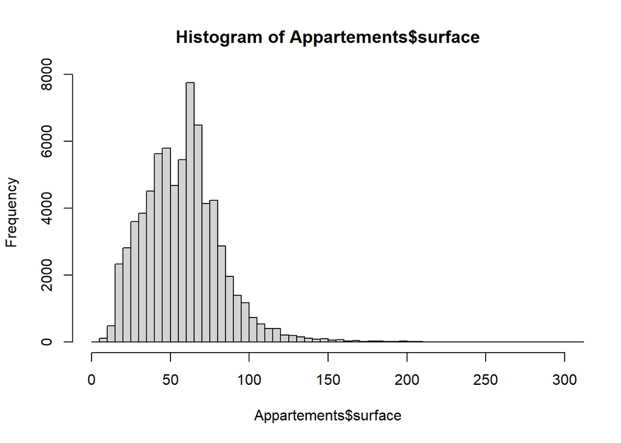

```r
hist(Appartements$surface, nclass = 500, xlim = c(0,300))
```

### 1.4.5 Etape 6 -> Sélection des bornes de prix et de surface

```r
etape6 <- etape5 %>% filter(between(prix, 15000, 5000000)) %>%
                     filter(case_when(type == 'Appartement' ~ between(surface, 10, 200)) |
                            case_when(type == 'Maison' ~ between(surface, 10, 350)))
```

## 1.5 Calcul du prix au m² et exclusion des valeurs extrêmes et aberrantes

### 1.5.1 Etape7 -> Calcul de la variable prix/m²

```r
etape7 <- etape6 %>% mutate(prixm2 = prix/surface)
```

### 1.5.2 Etape8 -> Sélection des bornes de prix au m²

#### 1.5.2.1 Fixer un seuil minimal des prix au m² (percentile)

```r
quantile(etape7$prixm2, 0.01)
```

```
##       1%
## 333.3333
```

#### 1.5.2.2 Fixer un seuil maximal des prix au m² (histogramme)

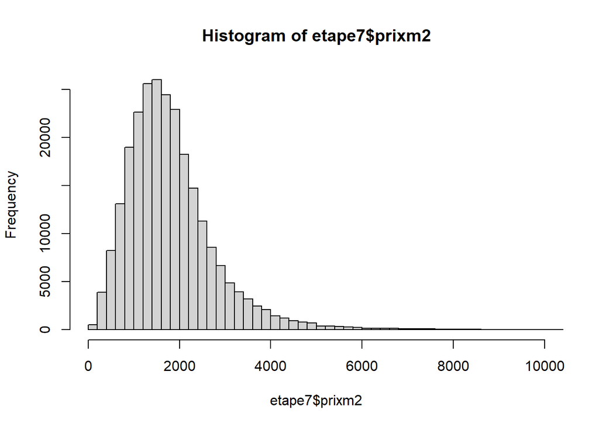

```r
hist(etape7$prixm2, breaks = 1000, xlim = c(0,10000))
```

#### 1.5.2.3 Filtres des valeurs

```r
etape8 <- etape7 %>% filter(between(prixm2, 330, 8000))
```

#### 1.5.2.4 Extraction de l’année à partir de la date

```r
etape8 <- etape8 %>% mutate(annee = substr(etape8$date, 1, 4))
```

#### 1.5.2.5 Arrondir les valeurs

```r
etape8$prix <- round(etape8$prix)
etape8$prixm2 <- round(etape8$prixm2)
```

## 1.6 Enrichissement des mutations avec de nouvelles variables

### 1.6.1 Etape9 -> Ajout de variables relatives à la commune et à l’EPCI (Liste des communes du Code Officiel Géographique)

```r
COG <- read.csv("Donnees/COG.csv", sep = ",", encoding = "UTF-8")
COG <- COG %>% mutate(codecommune = CODGEO)
etape9 <- merge(etape8, COG, by = "codecommune")
```

### 1.6.2 Etape10 -> Ajout de variables relatives au département (Liste des départements du Code Officiel Géographique)

```r
Dep <- read.csv("Donnees/departement2020.csv", encoding = "UTF-8", sep = ";")
Dep <- Dep %>% mutate(DEP = dep)
etape10 <- merge(etape9, Dep, by = "DEP")
```

### 1.6.3 Etape11 -> Ajout de la catégorisation des communes de l’Insee

```r
TYPOINSEE <- read.csv("Donnees/TYPOINSEE.csv", sep = ",", encoding = "UTF-8")
TYPOINSEE <- TYPOINSEE %>% mutate(codecommune = Code)
etape11 <- merge(etape10, TYPOINSEE, by = "codecommune")
```

### 1.6.4 Etape12 -> Structuration du jeu de données final

```r
DVFOK <- etape11 %>% select(id, date, annee, type, prix, surface, prixm2, codecommune, commune = LIBGEO, Dep = nccenr, EPCI = LIBEPCI, Typo_INSEE = typo, latitude, longitude)
```

### 1.6.5 Exporter le jeu de données final en csv

```r
dir.create("Resultats")
write.csv(DVFOK, 'Resultats/DVFOK.csv', quote = FALSE, row.names = FALSE)
```

### 1.6.6 Diagnostic des types de mutations

#### 1.6.6.1 Calcul du nombre de mutations distinctes

```r
length(unique(etape3$id))
```

```
## [1] 266082
```

#### 1.6.6.2 Nombre de mutations multiventes

```r
MutationsComplexes <- nbunique %>% filter(nb > 1)
length(unique(MutationsComplexes$id))
```

```
## [1] 12480
```

#### 1.6.6.3 Nombre de mutations monoventes (une seule ligne)

```r
uniquesimple <- etape3 %>%
  group_by(id) %>%
  summarise(
    prix = first(prix),
    surface = first(surface),
    nb = n()
  )

nbtransactionssimplemonoligne <- uniquesimple %>%
  filter(nb == 1)

nrow(nbtransactionssimplemonoligne)
```

```
## [1] 216735
```

#### 1.6.6.4 Nombre de mutations monoventes/multilignes

```r
A <- length(unique(etape3$id))
B <- nrow(nbtransactionssimplemonoligne)
A - B
```

```
## [1] 49347
```

#### 1.6.6.5 Diagnostic du nombre de biens par mutation

```r
diaggroup <- nbunique %>% mutate(as.character(nb)) %>% group_by(nb) %>% summarise(tot = n())
print(diaggroup)
```

```
## # A tibble: 27 × 2
##       nb    tot
##    <int>  <int>
##  1     1 253602
##  2     2   9179
##  3     3   1862
##  4     4    731
##  5     5    331
##  6     6    186
##  7     7     84
##  8     8     40
##  9     9     25
## 10    10     12
## # ℹ 17 more rows
```

#### 1.6.6.6 Nombre de mutations multiventes, nombre total et nombre moyen de biens associés

```r
length(MutationsComplexes$id)
```

```
## [1] 12480
```

```r
sum(MutationsComplexes$nb)
```

```
## [1] 31515
```

```r
mean(MutationsComplexes$nb)
```

```
## [1] 2.52524
```